# Remaining Analysis steps for the final project

# Add more information

## 1. Add plant resolution

We want to make a new column called plantResolution and assign it to “Family”, “Genus” or “Species” depending on the level of resolution associated taxa is resolved to.

```r
oba_2018_2019$plantTaxaWordCount <- str_count(oba_2018_2019$associatedTaxa, "\\w+")
head(oba_2018_2019$associatedTaxa, 10)
```

```
##  [1] "Vaccinium ovatum" ""                 ""                 "Whipplea modesta"
##  [5] "Whipplea modesta" ""                 ""                 ""
##  [9] ""                 "Horkelia fusca"
```

```r
head(oba_2018_2019$plantTaxaWordCount, 10)
```

```
##  [1] 2 0 0 2 2 0 0 0 0 2
```

```r
summary(oba_2018_2019$plantTaxaWordCount)
```

```
##    Min. 1st Qu.  Median    Mean 3rd Qu.    Max.
##   0.000   0.000   1.000   1.084   2.000   4.000
```

```r
plant_resolution_list <- rep(NA, nrow(oba_2018_2019))

for (i in seq_along(plant_resolution_list)) {
    word_count <- oba_2018_2019$plantTaxaWordCount[i]
    plant_name <- oba_2018_2019$associatedTaxa[i]

    if (word_count == 1) { # can be genus or family
        if (grepl("aceae$", plant_name)) { # family
            plant_resolution_list[i] <- "family"
        } else {
            plant_resolution_list[i] <- "genus"
        }
    } else if (word_count > 1) { # it is species/subspecies
        plant_resolution_list[i] <- "species"
    }
}
oba_2018_2019$plantResolution <- plant_resolution_list
head(oba_2018_2019$associatedTaxa, 10)
```

```
##  [1] "Vaccinium ovatum" ""                 ""                 "Whipplea modesta"
##  [5] "Whipplea modesta" ""                 ""                 ""
##  [9] ""                 "Horkelia fusca"
```

```r
head(oba_2018_2019$plantTaxaWordCount, 10)
```

```
##  [1] 2 0 0 2 2 0 0 0 0 2
```

```r
head(oba_2018_2019$plantResolution, 10)
```

```
##  [1] "species" NA        NA        "species" "species" NA        NA
##  [8] NA        NA        "species"
```

## 2. Add plant genus

Create a new column called plantGenus that is the genus if the associated taxa was resolved to species or genus, and NA if it was resolved to family.

```r
plant_genus_list <- rep(NA, nrow(oba_2018_2019))

for (i in seq_along(plant_genus_list)) {
    plant_res <- oba_2018_2019$plantResolution[i]
    plant_name <- oba_2018_2019$associatedTaxa[i]

    if (!is.na(plant_res) && (plant_res == "genus")) {
        plant_genus_list[i] <- plant_name
    } else if (!is.na(plant_res) && (plant_res == "species")) {
        plant_genus_list[i] <- strsplit(plant_name, " ")[[1]][1]
    }
}

oba_2018_2019$plantGenus <- plant_genus_list

head(oba_2018_2019$associatedTaxa, 10)
```

```
##  [1] "Vaccinium ovatum" ""                 ""                 "Whipplea modesta"
##  [5] "Whipplea modesta" ""                 ""                 ""
##  [9] ""                 "Horkelia fusca"
```

```r
head(oba_2018_2019$plantTaxaWordCount, 10)
```

```
##  [1] 2 0 0 2 2 0 0 0 0 2
```

```r
head(oba_2018_2019$plantResolution, 10)
```

```
##  [1] "species" NA        NA        "species" "species" NA        NA
##  [8] NA        NA        "species"
```

```r
head(oba_2018_2019$plantGenus, 10)
```

```
##  [1] "Vaccinium" NA          NA          "Whipplea"  "Whipplea"  NA
##  [7] NA          NA          NA          "Horkelia"
```

# Save/Read the new dataframe as csv

## Drop the columns that we are not going to use

```r
col_to_save <- c(
    "gbifID", "genericName", "specificEpithet", "species", "sex",
    "taxonRank", "eventDate", "year", "month", "samplingProtocol",
    "associatedTaxa", "county", "decimalLatitude", "decimalLongitude",
    "plantResolution", "plantGenus"
)
oba_2018_2019 <- oba_2018_2019[, col_to_save]
colnames(oba_2018_2019)
```

```
##  [1] "gbifID"           "genericName"      "specificEpithet"  "species"
##  [5] "sex"              "taxonRank"        "eventDate"        "year"
##  [9] "month"            "samplingProtocol" "associatedTaxa"   "county"
## [13] "decimalLatitude"  "decimalLongitude" "plantResolution"  "plantGenus"
```

## Save

```r
write.csv(oba_2018_2019, "data/cleaned_oba_2018_2019.csv", row.names = FALSE)
```

## Read

```r
oba_2018_2019 <- read.csv("data/cleaned_oba_2018_2019.csv")
```

```r
# check if all values of column gbifID are unique
unique_gbifID <- length(unique(oba_2018_2019$gbifID))
total_gbifID <- nrow(oba_2018_2019)

if (unique_gbifID == total_gbifID) {
    print("All values of column 'gbifID' are unique.")
} else {
    print("Not all values of column 'gbifID' are unique.")
}
```

```
## [1] "All values of column 'gbifID' are unique."
```

This means we can use gbifID as a unique identifier

# 1. Sexual Dimorphism

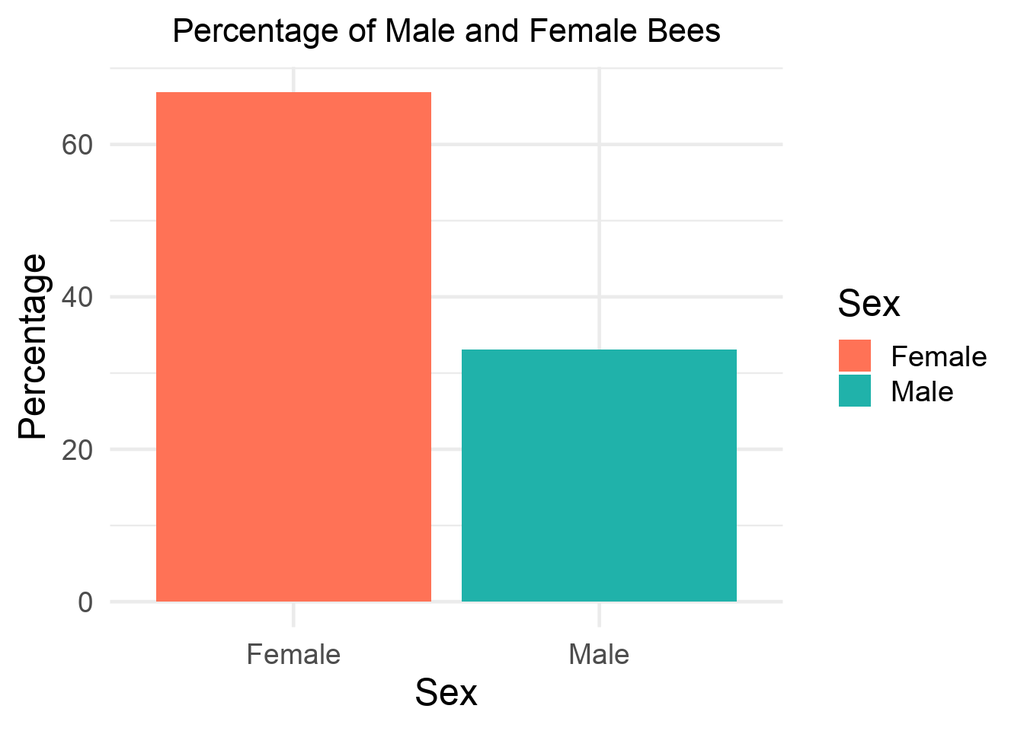

```r
# check the TOTAL PERCENTAGE of MALE vs FEMALE bees caught
total_male <- sum(oba_2018_2019$sex == "MALE", na.rm = TRUE)
total_female <- sum(oba_2018_2019$sex == "FEMALE", na.rm = TRUE)
total_bees <- nrow(oba_2018_2019)

percentage_male <- (total_male / total_bees) * 100
percentage_female <- (total_female / total_bees) * 100

# Create a data frame for the plot
sex_per_df <- data.frame(
    Sex = c("Female", "Male"),
    Percentage = c(percentage_female, percentage_male)
)

# Create a bar plot with ggplot
p_title <- "Percentage of Male and Female Bees"
p <- ggplot(sex_per_df, aes(x = Sex, y = Percentage, fill = Sex)) +
    geom_bar(stat = "identity") +
    scale_fill_manual(values = c("coral1", "lightseagreen")) +
    labs(x = "Sex", y = "Percentage") +
    ggtitle(p_title) +
    theme_minimal(18) +
    theme(
        axis.text = element_text(size = 14),
        plot.title = element_text(hjust = 0.5, size = 16)
    )
p
```

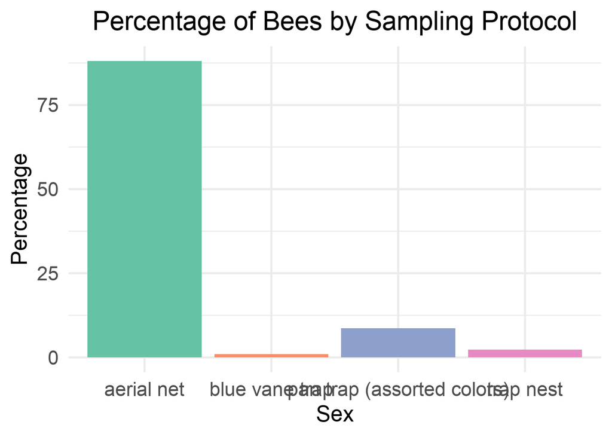

```r
ggsave(glue("plots/{p_title}.png"), dpi = 300, plot = p)
# Calculate the percentage of bees caught using different sampling patterns
sampling_patterns <- unique(oba_2018_2019$samplingProtocol)
percentage_per_pattern <- sapply(sampling_patterns, function(pattern) {
    total_bees <- sum(oba_2018_2019$samplingProtocol == pattern, na.rm = TRUE)
    percentage <- (total_bees / nrow(oba_2018_2019)) * 100
    return(percentage)
})

sampling_per_df <- data.frame(
    patterns = sampling_patterns,
    percentage = percentage_per_pattern
)

# Create a stacked bar plot with percentages
p_title <- "Percentage of Bees by Sampling Protocol"
p <- ggplot(sampling_per_df, aes(x = patterns, y = percentage, fill = patterns)) +
    geom_bar(stat = "identity", position = "stack", show.legend = F) +
    labs(x = "Sex", y = "Percentage", fill = "Sampling Protocol") +
    ggtitle(p_title) +
    theme_minimal(18) +
    theme(
        axis.text = element_text(size = 16),
        plot.title = element_text(hjust = 0.5)
    ) +
    scale_fill_brewer(palette = "Set2")
p
```